# CSP4141_InclassMultiseason Occupancy Simulation and Model Selection Exercise

### First load required packages.

**If you need to install the packages, you can do so directly in R Studio (Tools –> Install Packages or Packages –> Install), or you can use commands like these in your R Script: install.packages(“unmarked”). Once downloaded, you’ll need to call the packages you want to use in R using library(packagename) or require(packagename). When you call a package, R automatically calls other packages that are needed.**

```r
library(unmarked)
library(AICcmodavg)
library(MASS)
```

### Now simulate some presence/absence data (or rather, detection/non-detection data), this time over multiple seasons.

```r
M<-250 # number of sites
J<-5   # number of years (primary occasions)
K<-3   # occasions (secondary occasions)
```

### Now pick some values for occupancy and detection parameters (slopes and intercepts).

**We also create a site-level covariate, X1, that influences initial occupancy (psi) and a site, year, and occasion specific covariate, X2, that influences detection. Here, a = parameters related to occupancy and b = parameters related to detection; note that these are on the *logit* scale.**

```r
# Initial occupancy
a0<--0.25 # initial occupancy intercept
a1<-0.50  # slope for site-level occupancy covariate
X1<-runif(M,-3,3) # generate some random values for the site-level initial occupancy covariate, X1 (standardized)
psi<-plogis(a0 + a1*X1) # calculate initial site-specific occupancy probabilities

# Detection
b0<-1.00 # detection intercept
b1<-0.50 # slope for site-level detection covariate
b2<--0.20 # slope for observation-level covariate
X2<-array(NA,dim = c(M,K,J)) # Empty array for site-level detection covariate, X2 (standardized)
### Create an occasion-specific detection covariate, X2
for (i in 1:M){
    for (k in 1:K){
      for (j in 1:J){
        X2[i,k,j]<-runif(1,-3,3)
      } # Years
   } # Occasions
} # Sites
```

### Now we’re going to create 2 year-specific, site-level covariates, X3 and X4

**Note that X3 and X4 are correlated continuous covariates.**

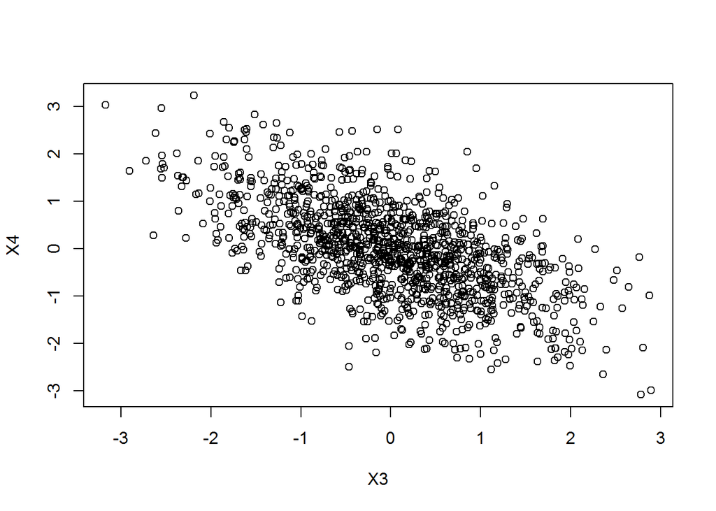

```r
# Year-specific, site-level covariates X3 and X4, which are slightly negatively correlated with mean 0, variance = 1, covariance = -0.6.
yearcovs <- as.data.frame(mvrnorm(M*J, mu = c(0,0),
                     Sigma = matrix(c(1,-0.6,-0.6,1), ncol = 2),
                     empirical = TRUE))
names(yearcovs)<-c("X3","X4")
X3<-array(yearcovs$X3,dim=c(M,J)) # year-specific, site-level covariate X3
X4<-array(yearcovs$X4,dim=c(M,J)) # year-specific, site-level covariate X4

# plot correlated covariates and take a look
plot(X3,X4)
```

### Now we need coefficients for the colonization and extinction models (the parameters driving temporal changes in occupancy).

**Here, g = parameters related to colonization (gamma) and e = parameters related to extinction (epsilon). Like occupancy and detection, these are also on the logit scale as colonization an extinction are probabilities. Note that there are only J-1 possible transition probabilities associated with epsilon and gamma, so we use an array with dimensions M (rows = number of sites) and J-1 (columns = the number of intervals over which occupancy could change). Here, column 1 of each array is associated with the first interval, or the time between survey occasions 1 and 2.**

```r
g0<--1.00 # colonization intercept
g1<- 0.50 # slope for site-level colonization covariate
g2<--1.50 # slope for year-specific site-level colonization covariate
gamma<-array(dim = c(M,J-1)) # array for colonization probabilties

# Extinction
e0<--1.25 # extinction intercept
e1<- 0.50 # slope for site-level extinction intercept
e2<--0.50 # slope for year-specific site-level covariate
epsilon<-array(dim = c(M,J-1)) # array for extinction probabilities
```

### Now create some empty arrays for use in the simulation.

```r
# Additional empty arrays/matrices, used below
z<-array(dim=c(M,J)) # latent occupancy state, indexed by Site and Year
muZ<-array(dim=c(M,J)) # occupancy probability, indexed by Site and Year
y<-array(dim = c(M,K,J)) # array for detection/non-detection data, indexed by Site, Occasion, Year
p<-array(dim = c(M,K,J)) # detection probability array (indexed by site, occasion, year)
prob<-array(dim = c(M,K,J)) # array for effective detection probability (z*p)
```

### Now calculate occasion specific detection probabilities.

```r
for (i in 1:M){
    for (k in 1:K){
      for (j in 1:J){
        p[i,k,j]<-plogis(b0 + b1*X1[i] + b2*X2[i,k,j])
    }
  }
}
```

### Now calculate site and year-specific colonization (gamma) and extinction (epsilon) probabilities.

**Note that although there are 5 years over which we’re simulating occupancy, there are only 4 transitions (4 intervals, here J-1 intervals) over which colonization and extinction events occur. For the ‘colext’ function, unmarked requires that site by year covariates are formatted as a site by year matrix (M x J), which in this case is a 250 x 5 matrix, but unmarked will assume that the first column of the site by year covariate matrix is associated with the first interval, which means that the final column of the site by year covariate matrix is ignored (i.e., it corresponds to an interval that never happened). This is important to keep in mind when formatting data for this type of model in unmarked.**

```r
for (i in 1:M){
  for (j in 1:(J-1)){
      gamma[i,j]<-plogis(g0 + g1*X1[i] + g2*X3[i,j])
      epsilon[i,j]<-plogis(e0 + e1*X1[i] + e2*X4[i,j])
    }
}
```

### Now determine intitial occupancy state (latent occupancy z in season 1).

```r
z[,1]<-rbinom(M,1,psi)
```

### Then simulate state process, or temporal changes in occupancy conditional upon intital state.

```r
for (i in 1:M){
  for (j in 2:J){
  muZ[i,j]<-z[i,j-1]*(1-epsilon[i,j-1]) + (1-z[i,j-1])*gamma[i,j-1]
  z[i,j]<-rbinom(1,1,muZ[i,j])
   }
}
```

### Then simulate detection/nondetection data (i.e., survey data).

```r
for (i in 1:M){
    for (k in 1:K){
      for (j in 1:J){
        prob[i,k,j]<-z[i,j]*p[i,k,j]
        y[i,k,j]<-rbinom(1,1,prob[i,k,j])
    }
  }
}
```

### Now that we’ve got the data simulated, we can get things ready for unmarked.

```r
sitecovs<-data.frame(X1) # site covariate X1 is a data frame
head(sitecovs)
```

```
##           X1
## 1  1.4263857
## 2 -1.1748503
## 3  2.0798342
## 4 -1.1847794
## 5 -2.2495240
## 6 -0.5012937
```

```r
# Reformat observation data and convert to data frame for unmarked as an M X T*J matrix
yfin<-matrix(y,nrow(y),J*K, byrow = F)
head(yfin)
```

```
##      [,1] [,2] [,3] [,4] [,5] [,6] [,7] [,8] [,9] [,10] [,11] [,12] [,13] [,14] [,15]
## [1,]    1    1    1    0    0    0    0    0    0     0     1     1     0     1     1
## [2,]    0    0    0    0    0    0    0    0    0     0     0     0     0     0     0
## [3,]    1    1    1    0    0    0    0    0    1     1     0     1     1     1     1
## [4,]    0    0    0    0    0    0    0    0    0     0     0     0     0     0     0
## [5,]    0    0    0    0    0    0    0    0    0     0     0     0     0     0     0
## [6,]    0    0    0    0    0    0    0    0    0     0     0     0     1     1     1
```

```r
# Reformat observation-level covariates (influencing p) as an M X T*J matrix
X2fin<-matrix(X2,nrow(X2),J*K, byrow = F)
round(head(X2[,,1]),2) # look at X2 before reformatting - this is for season 1
```

```
##       [,1]  [,2]  [,3]
## [1,]  1.96 -0.22 -1.59
## [2,] -0.05  1.77 -0.03
## [3,] -2.54 -2.33  0.27
## [4,]  2.03 -2.03  2.50
## [5,] -0.12  1.48 -2.27
## [6,]  2.97 -2.83 -2.17
```

```r
round(head(X2[,,2]),2) # X2 for season 2
```

```
##       [,1]  [,2]  [,3]
## [1,] -0.55  2.48 -2.33
## [2,] -1.68 -0.86 -2.80
## [3,] -2.13  0.60  0.58
## [4,] -0.26 -0.44  2.20
## [5,] -1.35  0.85 -2.84
## [6,] -1.37  1.86 -0.51
```

```r
round(head(X2fin),2) # the properly formatted matrix
```

```
##       [,1]  [,2]  [,3]  [,4]  [,5]  [,6]  [,7]  [,8]  [,9] [,10] [,11] [,12] [,13] [,14] [,15]
## [1,]  1.96 -0.22 -1.59 -0.55  2.48 -2.33 -2.84 -1.56 -0.15  2.88 -0.44  1.79  1.41  1.30 -1.47
## [2,] -0.05  1.77 -0.03 -1.68 -0.86 -2.80 -0.72  2.30  2.36 -2.03 -2.74 -0.95  0.69 -1.11 -0.90
## [3,] -2.54 -2.33  0.27 -2.13  0.60  0.58  1.27  1.29  2.29 -2.10  1.46  2.27 -2.49 -2.77  0.33
## [4,]  2.03 -2.03  2.50 -0.26 -0.44  2.20 -1.41  0.71  0.23  1.28  0.46  0.50 -0.69  0.29 -0.50
## [5,] -0.12  1.48 -2.27 -1.35  0.85 -2.84  1.25  1.61  1.83  1.24  1.41  0.76 -2.23  0.93  1.70
## [6,]  2.97 -2.83 -2.17 -1.37  1.86 -0.51  2.66  2.40  2.66  2.79  1.22  0.68 -0.79 -2.19 -0.11
```

```r
# And finally create an "unmarkedMultFrame"
SimDat<-unmarkedMultFrame(y = yfin,numPrimary=J,siteCovs=sitecovs,obsCovs=list(X2=X2fin),yearlySiteCovs=list(X3=X3,X4=X4))
```

### Finally, we can fit the model in unmarked using the ‘colext’ function.

```r
SimMod1<- colext(psiformula=~X1,gammaformula=~X1+X3,epsilonformula=~X1+X4,pformula=~X1+X2,data=SimDat)

SimMod2<- colext(psiformula=~X1,gammaformula=~X1+X3+X4,epsilonformula=~X1+X3+X4,pformula=~X1+X2,data=SimDat)

summary(SimMod1) # look at estimates and compare with simulated values
```

```
##
## Call:
## colext(psiformula = ~X1, gammaformula = ~X1 + X3, epsilonformula = ~X1 +
##     X4, pformula = ~X1 + X2, data = SimDat)
##
## Initial (logit-scale):
##             Estimate     SE     z  P(>|z|)
## (Intercept)   -0.169 0.1437 -1.18 2.39e-01
## X1             0.503 0.0907  5.54 2.97e-08
##
## Colonization (logit-scale):
##             Estimate     SE     z  P(>|z|)
## (Intercept)   -1.076 0.1430 -7.53 5.15e-14
## X1             0.662 0.0877  7.55 4.47e-14
## X3            -1.566 0.1838 -8.52 1.57e-17
##
## Extinction (logit-scale):
##             Estimate     SE     z  P(>|z|)
## (Intercept)   -1.627 0.1683 -9.66 4.35e-22
## X1             0.634 0.0955  6.64 3.22e-11
## X4            -0.693 0.1323 -5.24 1.62e-07
##
## Detection (logit-scale):
##             Estimate     SE     z  P(>|z|)
## (Intercept)    0.951 0.0599 15.86 1.13e-56
## X1             0.518 0.0386 13.43 3.95e-41
## X2            -0.190 0.0324 -5.87 4.39e-09
##
## AIC: 3164.428
## Number of sites: 250
## optim convergence code: 0
## optim iterations: 59
## Bootstrap iterations: 0
```

```r
summary(SimMod2) # look at estimates and compare with simulated values
```

```
##
## Call:
## colext(psiformula = ~X1, gammaformula = ~X1 + X3 + X4, epsilonformula = ~X1 +
##     X3 + X4, pformula = ~X1 + X2, data = SimDat)
##
## Initial (logit-scale):
##             Estimate     SE     z  P(>|z|)
## (Intercept)   -0.166 0.1435 -1.15 2.49e-01
## X1             0.502 0.0901  5.57 2.55e-08
##
## Colonization (logit-scale):
##             Estimate     SE     z  P(>|z|)
## (Intercept)   -1.082 0.1445 -7.49 7.05e-14
## X1             0.674 0.0892  7.55 4.20e-14
## X3            -1.801 0.2252 -8.00 1.27e-15
## X4            -0.335 0.1630 -2.06 3.97e-02
##
## Extinction (logit-scale):
##             Estimate     SE      z  P(>|z|)
## (Intercept)   -1.626 0.1677 -9.692 3.25e-22
## X1             0.632 0.0951  6.643 3.07e-11
## X3            -0.134 0.1457 -0.923 3.56e-01
## X4            -0.777 0.1594 -4.874 1.09e-06
##
## Detection (logit-scale):
##             Estimate     SE     z  P(>|z|)
## (Intercept)    0.949 0.0600 15.83 1.91e-56
## X1             0.518 0.0385 13.44 3.60e-41
## X2            -0.190 0.0324 -5.87 4.36e-09
##
## AIC: 3163.318
## Number of sites: 250
## optim convergence code: 0
## optim iterations: 65
## Bootstrap iterations: 0
```

### Create AIC table.

**If necessary, note that AIC values can be adjusted with estimate of ‘c-hat’ resulting from the GoF test that follows. Values >1.4 or so indicate lack of fit.**

```r
aictab(list('Model 1' = SimMod1, 'Model 2' = SimMod2),c.hat=1)
```

```
##
## Model selection based on AICc:
##
##          K    AICc Delta_AICc AICcWt Cum.Wt       LL
## Model 2 13 3164.86       0.00   0.58   0.58 -1568.66
## Model 1 11 3165.54       0.68   0.42   1.00 -1571.21
```

### Goodness of fit: MacKenzie and Bailey chi-square test statistic.

**Ideally nsim should be in the hundreds or thousands, but it takes a while so we’ll only do 10 here.**

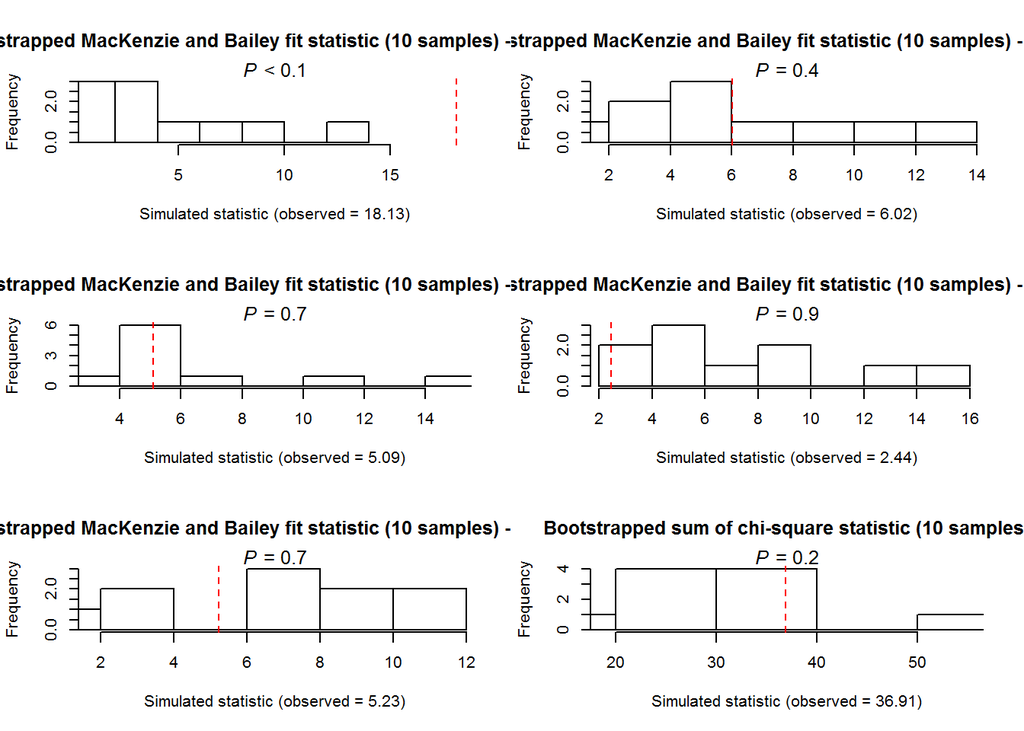

```
##
## Goodness-of-fit for dynamic occupancy model
##
## Number of seasons:  5
##
## Chi-square statistic:
## Season 1 Season 2 Season 3 Season 4 Season 5
##  18.1309   6.0206   5.0854   2.4438   5.2272
##
## Total chi-square = 36.9079
## Number of bootstrap samples = 10
## P-value = 0.2
##
## Quantiles of bootstrapped statistics:
##   0%  25%  50%  75% 100%
##   19   25   32   34   55
##
## Estimate of c-hat = 1.15
```

```r
mb.gof.test(SimMod1,print.table=TRUE,nsim=10,plot.hist=TRUE,plot.seasons=TRUE)
```